# **Par : Mohammed BENAHDJ**

## Prediction de prix des voiture

## Introduction :

```python
import pandas as pd
import numpy as np
import matplotlib.pyplot as plt
import seaborn as sns
```

```python
df_test=pd.read_csv("test.csv", encoding='latin1')
df_train = pd.read_csv('train.csv', encoding='latin1')
```

```python
df_train.head()
```

|  | ID | Price | Levy | Manufacturer | Model | Prod. year | Category | Leather interior | Fuel type | Engine volume | Mileage | Cylinders | Gear box type | Drive wheels | Doors | Wheel | Color | Airbags |
| --- | --- | --- | --- | --- | --- | --- | --- | --- | --- | --- | --- | --- | --- | --- | --- | --- | --- | --- |
| 0 | 45654403 | 13328 | 1399 | LEXUS | RX 450 | 2010 | Jeep | Yes | Hybrid | 3.5 | 186005 km | 6.0 | Automatic | 4x4 | 04-May | Left wheel | Silver | 12 |
| 1 | 44731507 | 16621 | 1018 | CHEVROLET | Equinox | 2011 | Jeep | No | Petrol | 3 | 192000 km | 6.0 | Tiptronic | 4x4 | 04-May | Left wheel | Black | 8 |
| 2 | 45774419 | 8467 | - | HONDA | FIT | 2006 | Hatchback | No | Petrol | 1.3 | 200000 km | 4.0 | Variator | Front | 04-May | Right-hand drive | Black | 2 |
| 3 | 45769185 | 3607 | 862 | FORD | Escape | 2011 | Jeep | Yes | Hybrid | 2.5 | 168966 km | 4.0 | Automatic | 4x4 | 04-May | Left wheel | White | 0 |
| 4 | 45809263 | 11726 | 446 | HONDA | FIT | 2014 | Hatchback | Yes | Petrol | 1.3 | 91901 km | 4.0 | Automatic | Front | 04-May | Left wheel | Silver | 4 |

## La siginification de colonnes de dataset:

**Price :** Le prix de la voiture.  
**Manufacturer :** Le fabricant de la voiture.  
**Model :** Le modèle de la voiture.  
**Prod. year :** L'année de production de la voiture.  
**Category :** La catégorie de la voiture (par exemple, Jeep, Hatchback).  
**Leather interior :** Si la voiture a un intérieur en cuir (Oui/Non).  
**Fuel type :** Le type de carburant utilisé par la voiture (par exemple, Hybride, Essence).  
**Engine volume :** Le volume du moteur de la voiture.  
**Mileage :** Le kilométrage de la voiture.  
**Cylinders :** Le nombre de cylindres dans le moteur de la voiture.  
**Gear box type :** Le type de boîte de vitesses (par exemple, Automatique, Tiptronic).  
**Drive wheels :** Le type de roues motrices (par exemple, 4x4, Avant).  
**Doors :** Le nombre de portes de la voiture.  
**Wheel :** La position du volant de la voiture (par exemple, Volant à gauche, Conduite à droite).  
**Color :** La couleur de la voiture.  
**Airbags :** Le nombre d'airbags dans la voiture

## Analyse des Valeurs Manquantes dans l'Ensemble de Données d'Entraînement

```python
df_train.isna().sum()
```

```
ID                  0
Price               0
Levy                0
Manufacturer        0
Model               0
Prod. year          0
Category            0
Leather interior    0
Fuel type           0
Engine volume       0
Mileage             0
Cylinders           0
Gear box type       0
Drive wheels        0
Doors               0
Wheel               0
Color               0
Airbags             0
dtype: int64
```

Donc, l'ensemble de données d'entraînement ne présente aucune valeur manquante

```python
df_train.shape
```

```
(19237, 18)
```

```python
df_test.shape
```

```
(8245, 18)
```

```python
df_train.head()
```

|  | ID | Price | Levy | Manufacturer | Model | Prod. year | Category | Leather interior | Fuel type | Engine volume | Mileage | Cylinders | Gear box type | Drive wheels | Doors | Wheel | Color | Airbags |
| --- | --- | --- | --- | --- | --- | --- | --- | --- | --- | --- | --- | --- | --- | --- | --- | --- | --- | --- |
| 0 | 45654403 | 13328 | 1399 | LEXUS | RX 450 | 2010 | Jeep | Yes | Hybrid | 3.5 | 186005 km | 6.0 | Automatic | 4x4 | 04-May | Left wheel | Silver | 12 |
| 1 | 44731507 | 16621 | 1018 | CHEVROLET | Equinox | 2011 | Jeep | No | Petrol | 3 | 192000 km | 6.0 | Tiptronic | 4x4 | 04-May | Left wheel | Black | 8 |
| 2 | 45774419 | 8467 | - | HONDA | FIT | 2006 | Hatchback | No | Petrol | 1.3 | 200000 km | 4.0 | Variator | Front | 04-May | Right-hand drive | Black | 2 |
| 3 | 45769185 | 3607 | 862 | FORD | Escape | 2011 | Jeep | Yes | Hybrid | 2.5 | 168966 km | 4.0 | Automatic | 4x4 | 04-May | Left wheel | White | 0 |
| 4 | 45809263 | 11726 | 446 | HONDA | FIT | 2014 | Hatchback | Yes | Petrol | 1.3 | 91901 km | 4.0 | Automatic | Front | 04-May | Left wheel | Silver | 4 |

```python
df_train.info()
```

```
<class 'pandas.core.frame.DataFrame'>
RangeIndex: 19237 entries, 0 to 19236
Data columns (total 18 columns):
 #   Column            Non-Null Count  Dtype
---  ------            --------------  -----
 0   ID                19237 non-null  int64
 1   Price             19237 non-null  int64
 2   Levy              19237 non-null  object
 3   Manufacturer      19237 non-null  object
 4   Model             19237 non-null  object
 5   Prod. year        19237 non-null  int64
 6   Category          19237 non-null  object
 7   Leather interior  19237 non-null  object
 8   Fuel type         19237 non-null  object
 9   Engine volume     19237 non-null  object
 10  Mileage           19237 non-null  object
 11  Cylinders         19237 non-null  float64
 12  Gear box type     19237 non-null  object
 13  Drive wheels      19237 non-null  object
 14  Doors             19237 non-null  object
 15  Wheel             19237 non-null  object
 16  Color             19237 non-null  object
 17  Airbags           19237 non-null  int64
dtypes: float64(1), int64(4), object(13)
memory usage: 2.6+ MB
```

```python
df_train.describe()
```

|  | ID | Price | Prod. year | Cylinders | Airbags |
| --- | --- | --- | --- | --- | --- |
| count | 1.923700e+04 | 1.923700e+04 | 19237.000000 | 19237.000000 | 19237.000000 |
| mean | 4.557654e+07 | 1.855593e+04 | 2010.912824 | 4.582991 | 6.582627 |
| std | 9.365914e+05 | 1.905813e+05 | 5.668673 | 1.199933 | 4.320168 |
| min | 2.074688e+07 | 1.000000e+00 | 1939.000000 | 1.000000 | 0.000000 |
| 25% | 4.569837e+07 | 5.331000e+03 | 2009.000000 | 4.000000 | 4.000000 |
| 50% | 4.577231e+07 | 1.317200e+04 | 2012.000000 | 4.000000 | 6.000000 |
| 75% | 4.580204e+07 | 2.207500e+04 | 2015.000000 | 4.000000 | 12.000000 |
| max | 4.581665e+07 | 2.630750e+07 | 2020.000000 | 16.000000 | 16.000000 |

Ces statistiques fournissent un aperçu des caractéristiques centrales et de la dispersion des données pour chaque variable.

```python
columns_name=df_train['Manufacturer'].unique()
len(columns_name)
```

```
65
```

```python
df_train['Gear box type'].unique()
```

```
array(['Automatic', 'Tiptronic', 'Variator', 'Manual'], dtype=object)
```

```python
df_train['Fuel type'].unique()
```

```
array(['Hybrid', 'Petrol', 'Diesel', 'CNG', 'Plug-in Hybrid', 'LPG',
       'Hydrogen'], dtype=object)
```

```python
df_train['Model'].unique()
```

```
array(['RX 450', 'Equinox', 'FIT', ..., 'E 230 124', 'RX 450 F SPORT',
       'Prius C aqua'], dtype=object)
```

```python
df_train['Cylinders'].unique()
```

```
array([ 6.,  4.,  8.,  1., 12.,  3.,  2., 16.,  5.,  7.,  9., 10., 14.])
```

```python
df_train['Drive wheels'].unique()
```

```
array(['4x4', 'Front', 'Rear'], dtype=object)
```

```python
df_train['Mileage'].max()
```

```
'999999999 km'
```

```python
df_train.Category.unique()
```

```
array(['Jeep', 'Hatchback', 'Sedan', 'Microbus', 'Goods wagon',
       'Universal', 'Coupe', 'Minivan', 'Cabriolet', 'Limousine',
       'Pickup'], dtype=object)
```

```python
expensive=df_train[df_train['Price']==df_train['Price'].max()]
expensive
```

|  | ID | Price | Levy | Manufacturer | Model | Prod. year | Category | Leather interior | Fuel type | Engine volume | Mileage | Cylinders | Gear box type | Drive wheels | Doors | Wheel | Color | Airbags |
| --- | --- | --- | --- | --- | --- | --- | --- | --- | --- | --- | --- | --- | --- | --- | --- | --- | --- | --- |
| 16983 | 45812886 | 26307500 | - | OPEL | Combo | 1999 | Goods wagon | No | Diesel | 1.7 | 99999 km | 4.0 | Manual | Front | 02-Mar | Left wheel | Blue | 0 |

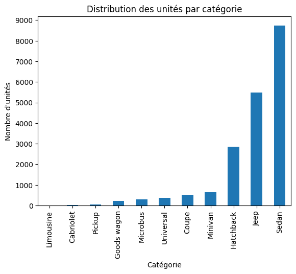

```python
data = df_train.groupby('Category').size()
data = data.sort_values()
data.plot(kind='bar')
plt.title('Distribution des unités par catégorie')
plt.xlabel('Catégorie')
plt.ylabel('Nombre d\'unités')
plt.yticks(range(0, 9500, 1000))
plt.savefig("Ncat.png")
plt.show()
```

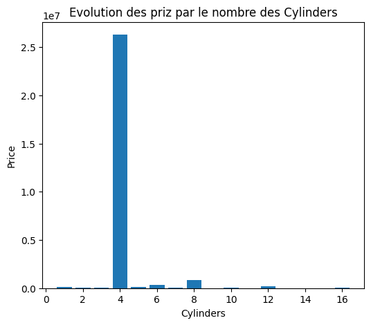

```python
plt.figure(figsize=(6,5))
plt.bar(df_train['Cylinders'], df_train['Price'])
plt.title("Evolution des priz par le nombre des Cylinders")
plt.xlabel("Cylinders")
plt.ylabel("Price")
plt.savefig("P-c.png")
plt.show()
```

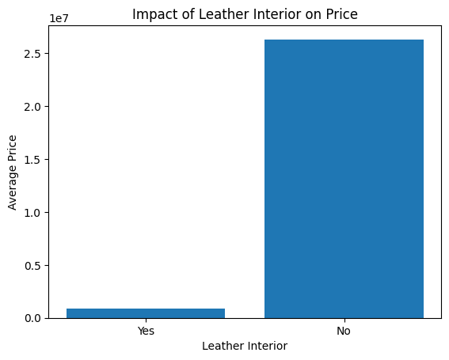

```python
plt.bar(df_train['Leather interior'], df_train['Price'])
plt.xlabel('Leather Interior')
plt.ylabel('Average Price')
plt.title('Impact of Leather Interior on Price')
plt.show()
```

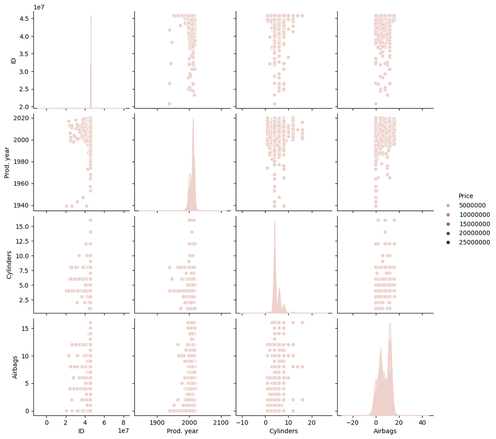

```python
sns.pairplot(data=df_train, hue="Price")
plt.show()
```

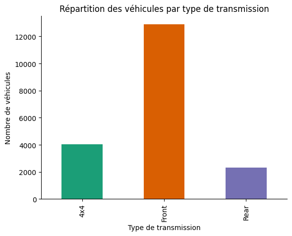

```python
grouped_data = df_train.groupby('Drive wheels').size()
grouped_data.plot(kind='bar', color=sns.color_palette('Dark2'))
plt.title('Répartition des véhicules par type de transmission')
plt.xlabel('Type de transmission')
plt.ylabel('Nombre de véhicules')
plt.gca().spines[['top', 'right']].set_visible(False)
plt.show()
```

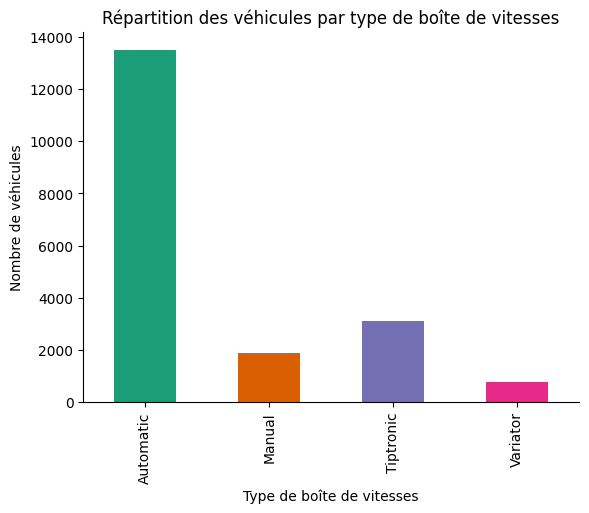

```python
grouped_data = df_train.groupby('Gear box type').size()
grouped_data.plot(kind='bar', color=sns.color_palette('Dark2'))
plt.title('Répartition des véhicules par type de boîte de vitesses')
plt.xlabel('Type de boîte de vitesses')
plt.ylabel('Nombre de véhicules')
plt.gca().spines[['top', 'right']].set_visible(False)
plt.show()
```

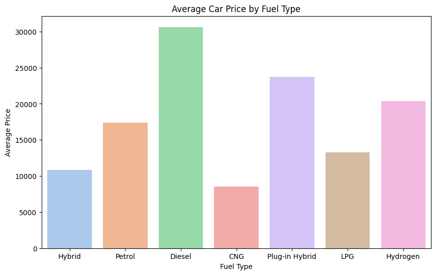

```python
plt.figure(figsize=(10, 6))
sns.barplot(x='Fuel type', y='Price', data=df_train, ci=None, palette='pastel')
plt.title('Average Car Price by Fuel Type')
plt.xlabel('Fuel Type')
plt.ylabel('Average Price')
plt.show()
```

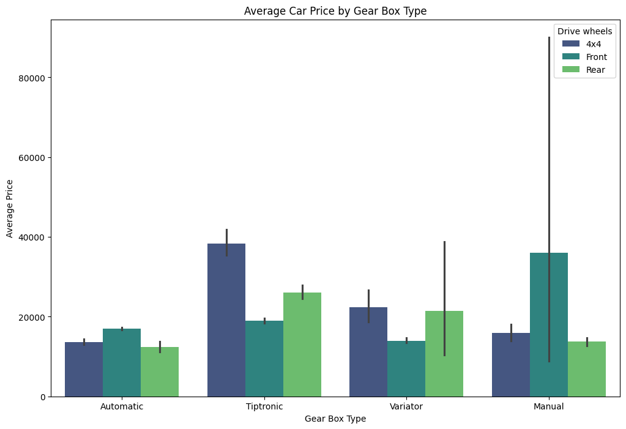

```python
plt.figure(figsize=(12, 8))
sns.barplot(x='Gear box type', y='Price', data=df_train, hue='Drive wheels', palette='viridis')
plt.title('Average Car Price by Gear Box Type')
plt.xlabel('Gear Box Type')
plt.ylabel('Average Price')
plt.show()
```

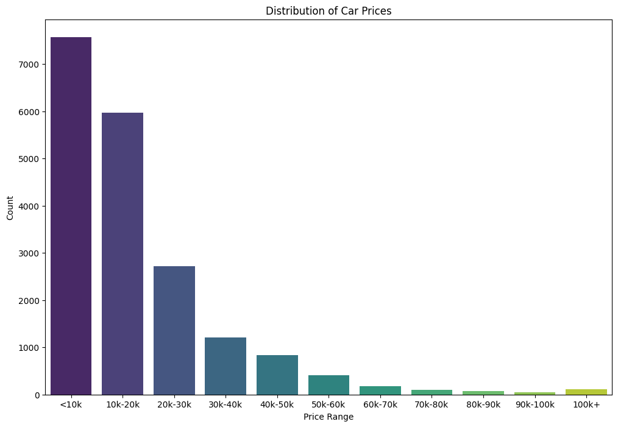

```python
price_bins = [0, 10000, 20000, 30000, 40000, 50000, 60000, 70000, 80000, 90000, 100000, float('inf')]
price_labels = ['<10k', '10k-20k', '20k-30k', '30k-40k', '40k-50k', '50k-60k', '60k-70k', '70k-80k', '80k-90k', '90k-100k', '100k+']

df_train['Price Range'] = pd.cut(df_train['Price'], bins=price_bins, labels=price_labels, right=False)
plt.figure(figsize=(12, 8))
sns.countplot(x='Price Range', data=df_train, order=price_labels, palette='viridis')
plt.title('Distribution of Car Prices')
plt.xlabel('Price Range')
plt.ylabel('Count')
plt.show()
```

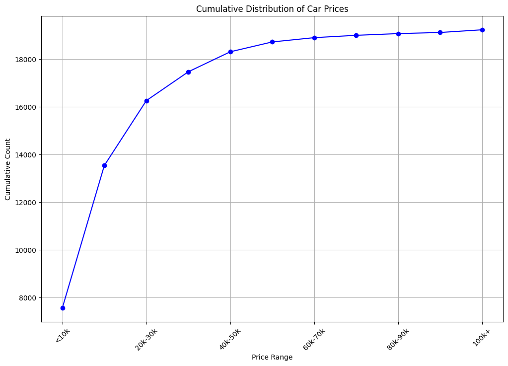

```python
price_bins = [0, 10000, 20000, 30000, 40000, 50000, 60000, 70000, 80000, 90000, 100000, float('inf')]
price_labels = ['<10k', '10k-20k', '20k-30k', '30k-40k', '40k-50k', '50k-60k', '60k-70k', '70k-80k', '80k-90k', '90k-100k', '100k+']

df_train['Price Range'] = pd.cut(df_train['Price'], bins=price_bins, labels=price_labels, right=False)
cumulative_count = df_train['Price Range'].value_counts().sort_index().cumsum()

plt.figure(figsize=(12, 8))
cumulative_count.plot(marker='o', linestyle='-', color='blue')
plt.title('Cumulative Distribution of Car Prices')
plt.xlabel('Price Range')
plt.ylabel('Cumulative Count')
plt.xticks(rotation=45)
plt.grid(True)
plt.show()
```

# Partie 2: Machine learning

importing des bibliotheques necessaire pour faire l'apprentissage

```python
from sklearn.model_selection import train_test_split
from sklearn.preprocessing import LabelEncoder
from sklearn.ensemble import RandomForestRegressor
from sklearn.neighbors import KNeighborsRegressor
from sklearn.linear_model import LinearRegression
from sklearn.tree import DecisionTreeRegressor
from sklearn.svm import SVR
import joblib
from sklearn.metrics import mean_squared_error, mean_absolute_error, r2_score
from sklearn.metrics import accuracy_score, confusion_matrix
import math
```

**Divise datasets d'apprentissage**

```python
X=df_train.drop(['ID','Levy','Price', 'Price Range'],axis=1)
y=df_train["Price"]
```

```python
X_train, X_test, y_train, y_test= train_test_split(X, y, random_state=42, test_size=0.2)
```

```python
encoder=LabelEncoder()
for col in X_train:
    X_train[col]=encoder.fit_transform(X_train[col])
y_train=encoder.fit_transform(y_train)

for col in X_test:
    X_test[col]=encoder.fit_transform(X_test[col])
y_test=encoder.fit_transform(y_test)
```

**Divise dataset de test**

```python
mses={}
r2s={}
```

## Parce que le dataset est grnade le d'apprentissage pour la majoritie des algorithms est plus grande, j'ai utilise google colab est un serveur ..., pour execute les algorithm vite et j'ai cree les modeles dans fichier .pkl est une methodes plus utilise pour la creation des modeles qui deja trained sur les donnees d'apprentissage, pour reduce le temps d'execution pour le programme

# **1. SVM model :**

```python
# svm_model = SVR(kernel='linear')
# svm_model.fit(X_train, y_train)
# joblib.dump(svm_model, 'svm_model.pkl')
```

```python
svm_model=joblib.load('svm_model.pkl')
```

```python
y_pred1=svm_model.predict(X_test)
```

```python
mse=mean_squared_error(y_test,y_pred1)
print(f"mean squared error : {mse}")
mses["svm"]=mse
r2=r2_score(y_test, y_pred1)
print(f"R2 : {r2}")
r2s["svm"]=r2
```

```
mean squared error : 129709.46781066112
R2 : -1.0260195116525108
```

# **2. Arbre de Decision pour Regression :**

```python
# tree_model = DecisionTreeRegressor(random_state=42)
# tree_model.fit(X_train, y_train)

# joblib.dump(tree_model, 'Decision_treee.pkl')
```

```python
decisionTreeModel=joblib.load('DesicionTreeRegression_model.pkl')
```

```python
y_pred2 =decisionTreeModel.predict(X_test)
mse = mean_squared_error(y_test, y_pred2)
print(f'Mean Squared Error: {mse}')
mses['DecisionTree']=mse
r2=r2_score(y_test, y_pred2)
print(f"R2 : {r2}")
r2s["DecisionTree"]=r2
```

```
Mean Squared Error: 129709.46781066112
R2 : -1.0260195116525108
```

# **3. LineaireRegression model :**

```python
# LRM=LinearRegression()
# LRM.fit(X_train, y_train)
# joblib.dump(LRM, "LineaireRegression_Simple_model.pkl")
```

```python
LRM=joblib.load('LineaireRegression_Simple_model.pkl')
```

```python
y_pred3=LRM.predict(X_test)
y_pred3
```

```
array([  23.71642611, -158.09474934, -507.47955156, ...,   95.87447386,
       -143.49225994,  222.22021236])
```

```python
mse = mean_squared_error(y_test, y_pred3)
print(f'Mean squared Error: {mse}')
mses["LineaireRegressionM"]=mse
r2=r2_score(y_test, y_pred3)
print(f"R2 : {r2}")
r2s["LineaireRegression"]=r2
```

```
Mean squared Error: 133674.1544958178
R2 : -1.087946622427813
```

# **4. RandomForestRegressor model :**

```python
# RandomForestModel = RandomForestRegressor(n_estimators=100, random_state=42)
# RandomForestModel.fit(X_train, y_train)

# joblib.dump(RandomForestModel, "Cars_Price_Prediction_model_RFR.pkl")
```

```python
RFR=joblib.load('Cars_Price_Prediction_model_RFR.pkl')
```

```python
y_pred4=RFR.predict(X_test)
```

```python
mse = mean_squared_error(y_test, y_pred4)
print(f'Mean squared Error: {mse}')
mses["RandomForest"]=mse
r2=r2_score(y_test, y_pred4)
print(f"R2 : {r2}")
r2s["RandomForest"]=r2
```

```
Mean squared Error: 87419.64331048862
R2 : -0.3654662688716652
```

# **5. KNN regressor model :**

```python
def k_value(X):
    sqrt_k=math.sqrt(len(X))
    if int(sqrt_k)%2!=0:
        k=int(sqrt_k)
    else :
        k=int(sqrt_k)-1
    return k
```

```python
# knn_model=KNeighborsRegressor(n_neighbors=k_value(X_train))
# knn_model.fit(X_train,y_train)

# joblib.dump(knn_model, "knn_model.pkl")
```

```python
knn=joblib.load("knn_model.pkl")
```

```python
y_pred5=knn.predict(X_test)
```

```python
mse = mean_squared_error(y_test, y_pred5)
print(f'Mean Squared Error: {mse}')
mses["knn"]=mse
r2=r2_score(y_test, y_pred5)
print(f"R2 : {r2}")
r2s["Knn"]=r2
```

```
Mean Squared Error: 106425.37112390957
R2 : -0.6623295282241393
```

# **6. Naives bayes**

```python
# from sklearn.naive_bayes import GaussianNB

# naive_bayes_model = GaussianNB()
# naive_bayes_model.fit(X_train, y_train)

# joblib.dump(naive_bayes_model, "NaiveBayesGaussian.pkl")
```

```python
NB=joblib.load("NaiveBayesGaussian.pkl")
y_pred6 = NB.predict(X_test)
```

```python
accuracy = accuracy_score(y_test, y_pred6)
print(f"Accuracy: {accuracy}")
```

```
Accuracy: 0.002858627858627859
```

```python
mse = mean_squared_error(y_test, y_pred6)
print(f'Mean Squared Error: {mse}')
mses["GaussianNB"]=mse
r2=r2_score(y_test, y_pred6)
print(f"R2 : {r2}")
r2s["GaussianNB"]=r2
```

```
Mean Squared Error: 131249.229989605
R2 : -1.0500700938536385
```

# **7. Logistic lineaire**

```python
# model_Logistic = LogisticRegression()
# model_Logistic.fit(X_train, y_train)

# joblib.dump(model_Logistic, "logisticRegression_model.pkl")
```

```python
LineaireLogistic=joblib.load("logisticRegression_model.pkl")
y_pred7=LineaireLogistic.predict(X_test)
```

```python
mse=mean_squared_error(y_test, y_pred7)
print("Mean squared error :", mse)
mses["LogisticRegression"]=mse
r2=r2_score(y_test, y_pred7)
print(f"R2 : {r2}")
r2s["LineaireLogistic"]=r2
```

```
Mean squared error : 155009.04547817048
R2 : -1.4211906495509665
```

```python
accuracy = accuracy_score(y_test, y_pred7)
print(f"Accuracy: {accuracy}")
```

```
Accuracy: 0.002858627858627859
```

# **Visualizer les les prediction**

```python
modeles={
    "SVM":y_pred1,
    "DecisionTree":y_pred2,
    "LineaireRegression":y_pred3,
    "RandomForest":y_pred4,
    "knn":y_pred5,
    "Naive Bayes":y_pred6,
    "LogisticLineaire":y_pred7
}
colors = {
    "SVM": 'red',
    "DecisionTree": 'blue',
    "LineaireRegression": 'green',
    "RandomForest": 'black',
    "knn": 'orange',
    "Naive Bayes": 'brown',
    "LogisticLineaire": 'pink'
}
```

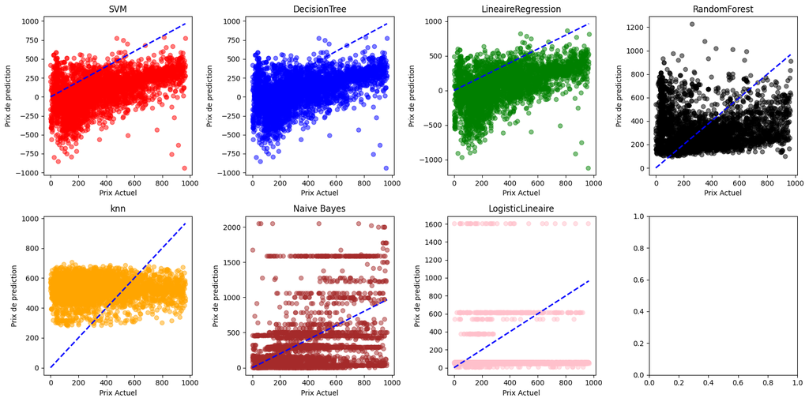

```python
actual_values=y_test
plt.figure(figsize=(12, 10))
fig, axes = plt.subplots(nrows=2, ncols=4, figsize=(16, 8))
axes = axes.flatten()
for i, (model_name, y_pred) in enumerate(modeles.items()):
    axes[i].scatter(actual_values, y_pred, label=model_name, color=colors[model_name], alpha=0.5)
    axes[i].plot([min(actual_values), max(actual_values)], [min(actual_values), max(actual_values)], '--', lw=2, color='blue', label='Perfect Predictions')
    axes[i].set_xlabel('Prix Actuel')
    axes[i].set_ylabel('Prix de prediction')
    axes[i].set_title(model_name)
plt.tight_layout()
plt.show()
```

# Comparaison des modèles de régression pour la prédiction des prix

```python
mses
```

```
{'svm': 129709.46781066112,
 'DecisionTree': 129709.46781066112,
 'LineaireRegressionM': 133674.1544958178,
 'RandomForest': 87419.64331048862,
 'knn': 106425.37112390957,
 'GaussianNB': 131249.229989605,
 'LogisticRegression': 155009.04547817048}
```

```python
min(mses.items(), key=lambda k: k[1])
```

```
('RandomForest', 87419.64331048862)
```

```python
r2s
```

```
{'svm': -1.0260195116525108,
 'DecisionTree': -1.0260195116525108,
 'LineaireRegression': -1.087946622427813,
 'RandomForest': -0.3654662688716652,
 'Knn': -0.6623295282241393,
 'GaussianNB': -1.0500700938536385,
 'LineaireLogistic': -1.4211906495509665}
```

```python
max(r2s.items(), key=lambda k: k[1])
```

```
('RandomForest', -0.3654662688716652)
```

```python
pred=pd.DataFrame()
pred["y_test"]=y_test
pred["SVM"]=y_pred1
pred["DecisonTree"]=y_pred2
pred["LineaireRegression"]=y_pred3
pred["RandomForest"]=y_pred4
pred["knn"]=y_pred5
pred["naif bays"]=y_pred6
```

```python
pred.sort_values('y_test')
```

|  | y_test | SVM | DecisonTree | LineaireRegression | RandomForest | knn | naif bays |
| --- | --- | --- | --- | --- | --- | --- | --- |
| 3380 | 0 | 201.837885 | 201.837885 | 241.456163 | 252.930000 | 533.869919 | 319 |
| 3344 | 0 | 261.863665 | 261.863665 | 295.145557 | 316.600000 | 595.788618 | 457 |
| 2700 | 0 | 417.370111 | 417.370111 | 495.096666 | 296.740000 | 517.260163 | 1677 |
| 2120 | 0 | -166.239703 | -166.239703 | -132.558130 | 338.643333 | 570.130081 | 2 |
| 2204 | 0 | -289.871623 | -289.871623 | -356.611447 | 191.440000 | 574.829268 | 117 |
| ... | ... | ... | ... | ... | ... | ... | ... |
| 952 | 962 | 275.268716 | 275.268716 | 339.396921 | 833.773947 | 449.756098 | 64 |
| 1975 | 963 | 390.095485 | 390.095485 | 378.387742 | 485.290000 | 572.682927 | 506 |
| 3573 | 964 | 278.466388 | 278.466388 | 416.290996 | 641.730000 | 560.691057 | 1504 |
| 1357 | 965 | 417.394898 | 417.394898 | 524.912879 | 625.680000 | 446.520325 | 1504 |
| 487 | 966 | 774.620102 | 774.620102 | 815.958912 | 911.520000 | 465.699187 | 1677 |

3848 rows × 7 columns

```python
pred.to_csv('comparing test and predicted values.csv')
```

```python
min(mses.items(), key=lambda k: k[1])
```

```
('RandomForest', 87419.64331048862)
```

```python
r2s
```

```
{'svm': -1.0260195116525108,
 'DecisionTree': -1.0260195116525108,
 'LineaireRegression': -1.087946622427813,
 'RandomForest': -0.3654662688716652,
 'Knn': -0.6623295282241393,
 'GaussianNB': -1.0500700938536385,
 'LineaireLogistic': -1.4211906495509665}
```

```python
max(r2s.items(), key=lambda k: k[1])
```

```
('RandomForest', -0.3654662688716652)
```

# Calculer mean_absolute_error

```python
maes=[]
```

```python
maes.append(mean_absolute_error(y_test,y_pred1))
maes.append(mean_absolute_error(y_test,y_pred2))
maes.append(mean_absolute_error(y_test,y_pred3))
maes.append(mean_absolute_error(y_test,y_pred4))
maes.append(mean_absolute_error(y_test,y_pred5))
maes.append(mean_absolute_error(y_test,y_pred6))
maes.append(mean_absolute_error(y_test,y_pred7))
```

```python
for i,mae in enumerate(maes):
    print("model N:",i+1,"-->" ,round(mae,2))
```

```
model N: 1 --> 302.7
model N: 2 --> 302.7
model N: 3 --> 301.71
model N: 4 --> 230.92
model N: 5 --> 284.29
model N: 6 --> 243.45
model N: 7 --> 294.43
```

The best model is model Number 4

```python
for i,val in enumerate(mses.values()):
    print("model N:", i+1, "-->", round(val,2))
```

```
model N: 1 --> 129709.47
model N: 2 --> 129709.47
model N: 3 --> 133674.15
model N: 4 --> 87419.64
model N: 5 --> 106425.37
model N: 6 --> 131249.23
model N: 7 --> 155009.05
```

the best model for mse is : model Number 4 too

```python
for i, val in enumerate(r2s):
    print(f"model N: {i+1} --> {val}")
```

```
model N: 1 --> svm
model N: 2 --> DecisionTree
model N: 3 --> LineaireRegression
model N: 4 --> RandomForest
model N: 5 --> Knn
model N: 6 --> GaussianNB
model N: 7 --> LineaireLogistic
```

#### **so the model number 4 is model of RandomForestRegressor**

# Faire la prediction sur le dataset de test utilisant le meilleure model ( RandomForestRegressor )

```python
X=df_test.drop(['ID', 'Levy', 'Price'], axis=1)
```

```python
for col in X:
    X[col]=encoder.fit_transform(X[col])
```

```python
prediction=RFR.predict(X)
```

```python
df_test["Price"]=prediction
```

```python
df_test
```

|  | ID | Levy | Manufacturer | Model | Prod. year | Category | Leather interior | Fuel type | Engine volume | Mileage | Cylinders | Gear box type | Drive wheels | Doors | Wheel | Color | Airbags | Price |
| --- | --- | --- | --- | --- | --- | --- | --- | --- | --- | --- | --- | --- | --- | --- | --- | --- | --- | --- |
| 0 | 44020629 | - | VOLKSWAGEN | Golf | 2012 | Hatchback | No | Diesel | 2.0 Turbo | 0 km | 4 | Manual | Front | 02-Mar | Left wheel | Grey | 10 | 333.70 |
| 1 | 45784798 | - | HYUNDAI | Sonata | 2012 | Sedan | Yes | Petrol | 2.4 | 26000 km | 4 | Tiptronic | Front | 04-May | Left wheel | Grey | 10 | 415.85 |
| 2 | 45800257 | - | NISSAN | Tiida | 2005 | Sedan | No | Petrol | 1.5 | 168000 km | 4 | Automatic | Front | 04-May | Right-hand drive | Sky blue | 8 | 201.75 |
| 3 | 45797981 | 975 | VOLVO | XC90 | 2012 | Jeep | Yes | Petrol | 3.2 | 143000 km | 6 | Automatic | 4x4 | 04-May | Left wheel | Blue | 12 | 675.28 |
| 4 | 45814303 | - | OPEL | Astra | 1993 | Hatchback | No | Petrol | 1.6 | 200000 km | 4 | Manual | Front | 04-May | Left wheel | Black | 0 | 130.43 |
| ... | ... | ... | ... | ... | ... | ... | ... | ... | ... | ... | ... | ... | ... | ... | ... | ... | ... | ... |
| 8240 | 44824410 | 1357 | FIAT | Stilo | 2004 | Universal | No | Petrol | 1.6 | 164000 km | 4 | Manual | Front | 04-May | Left wheel | Blue | 6 | 146.31 |
| 8241 | 45682346 | - | BMW | 528 F10 | 2012 | Sedan | Yes | Petrol | 2.8 Turbo | 156000 km | 4 | Tiptronic | Front | 04-May | Left wheel | Black | 6 | 427.52 |
| 8242 | 45649860 | 1646 | LEXUS | GX 460 | 2015 | Jeep | Yes | Petrol | 4.6 | 102907 km | 8 | Automatic | 4x4 | 04-May | Left wheel | Black | 0 | 295.43 |
| 8243 | 45809706 | 784 | TOYOTA | Aqua | 2017 | Hatchback | Yes | Petrol | 1.5 | 3000 km | 4 | Automatic | Front | 04-May | Left wheel | Green | 4 | 439.15 |
| 8244 | 45813163 | 448 | HONDA | Insight | 2012 | Hatchback | Yes | Hybrid | 1.3 | 321269 km | 4 | Automatic | Front | 04-May | Left wheel | Red | 12 | 363.12 |

8245 rows × 18 columns

```python
df_test.to_csv('df_test_predicted')
```